# lin01_1trd

#### Модуль 2. ФАЙЛЫ В LINUX

[fhs](http://www.pathname.com/fhs/)

`file -s /dev/sda1` - чтобы определить, какая файловая система на разделе /dev/sda1, наберите команду file с ключом -s  
`df -T` - показывает тип файловой системы.  
`du /var` - disk usage подсчитывает и выводит размер, занимаемый директорией  
`du -h -s /var 2>/dev/null` - 438M /var -s - summary -h - human `du --max-depth=1 /usr/share/` - `pwd` - path work directory  
`ls` - отобразить содержимое указанной директории  
`ls -a` - ... и ..  
`ls -li` - --inode  
`ls -l --time=ctime` -  
`ls -l --time=atime` -

```
mtime - modification time - время последней модификации (изменения) файла
atime - access time - время последнего доступа к файлу
ctime - change time - время последнего изменения атрибутов файла (данных которые хранятся в inode-области)
```

##### Каталоги

`pwd` - path work directory  
`.` - текущий каталог  
`..` - родительский каталог  
`ls -l` -

##### Переходы между директориями:

`cd ..` - перейти в директорию уровнем выше  
`cd ../..` -перейти в директорию двумя уровнями выше  
`cd` - перейти в домашнюю директорию  
`cd ~user` - user перейти в домашнюю директорию пользователя user  
`cd -` - перейти в директорию, в которой находились до перехода в текущую директорию  
`cd /user/user1` -  
`ls -a ~` -(~ - домашний каталог)  
`id` - uid=0(root) gid=0(root) группы=0(root)  
`whoami` - root  
`mkdir cat1` -  
`ls -l` - -rw-r--r-- 1 root root 155997 окт. 2 20:41 asterisk.tbz  
`rm f1` - remove file  
`rm -r d1` - remove recursive directory  
`cp f1 f2` - copy  
`cp /etc/passwd .` - оттуда в pwd  
`mv f1 f2` - Переименование , Перемещение, перемещение под другим именем.  
`` -

##### Каталоги

`pwd` - path work directory  
`id` - `tree -L 1 /` - `df -T` - `/boot/, /lib/, /lib64/, /home/, lost+found, media, mnt, opt, usr, var, tmp, proc,` -  
`cat /proc/cpuinfo` -  
`cat /proc/filesystems` -  
`cat /proc/loadavg` -  
`cat /proc/meminfo` -  
`ls /proc/sys` -  
`man sysctl` -  
`ls /proc/sys/kernel/` -  
`cat /proc/sys/kernel/hostname` - server.mydomain.org  
`ls /dev/` -  
`crw-rw----` - c - устройство, - - текстовый файл, d - direrctory , l - ссылка, b - блочное устройтво (диск)

```
root@server:~# ls -l /dev/ | grep sd
brw-rw---- 1 root disk      8,   0 окт  4 09:32 sda
brw-rw---- 1 root disk      8,   1 окт  4 09:32 sda1
```

`sda` - a- 1-й, sd - hd  
`file -s /dev/sda` -  
`cd ..` -  
`cd` -  
`cd -` -  
`cd ~mlapin` -  
`su mlapin` -  
`mkdir cat1` -  
`touch cat1/fl1.txt` -  
`cat > cat1/fl2.` -  
`:> cat1/fl2.` -  
`rmdir` -  
`rm cat1/fl2.` -  
`rm -r` -  
`mv cat1/fl1.txt cat1/fl3.txt` -  
`cp cat1/fl3.txt cat1/fl1.txt` -  
`init 0` - выход  
`-` -  
`-` -  
`` -

```
root@server:~# df -T
Файл.система   Тип      1K-блоков Использовано Доступно Использовано% Cмонтировано в
udev           devtmpfs    473804            0   473804            0% /dev
tmpfs          tmpfs       100912          704   100208            1% /run
/dev/sda1      ext4      10253588      3203788  6509232           33% /
tmpfs          tmpfs       504556            0   504556            0% /dev/shm
tmpfs          tmpfs         5120            0     5120            0% /run/lock
tmpfs          tmpfs       504556            0   504556            0% /sys/fs/cgroup
tmpfs          tmpfs       100908            0   100908            0% /run/user/0
```

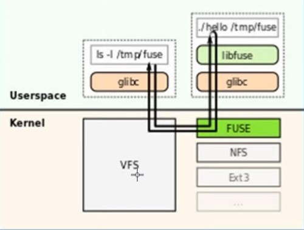

FUSE - file system and user space

##### Переходы между директориями:

##### Создание ссылок в Linux

ln файл ссылка - link name `ln file1 file2`

```
root@server:~# ln f2 f1
root@server:~# find . -samefile f2
./f2
./f1
```

`find / -samefile f1` - ищет ссылки от корня `ls -i` - 279170 asterisk 149994 ex1.sh 150844 f2 149284 asterisk.tbz 149997 ex2.sh 149996 ping_test1.sh 154105 cat1 150844 f1 149995 rm.txt `find / -inum 150844` - /root/f2 /root/cat1/f1 /root/f1

##### Символьную ссылку можно создать при помощи команды ln с ключом -s (от "symbolic").

`ln -s f1 slf1` - lrwxrwxrwx 1 root root 2 окт. 4 19:02 slf1 -> f1

##### Программы поиска файлов:

##### which, locate, find

`which` - показывает путь к каталогу указанного файла  
`which vim` - /usr/bin/vim

```
root@server:~# find / -name  vim
/etc/alternatives/vim
/etc/vim
/usr/bin/vim
/usr/share/bug/vim
/usr/share/vim
/usr/share/doc/vim
/usr/share/lintian/overrides/vim
/var/lib/vim
/var/lib/dpkg/alternatives/vim
root@server:~# locate -r 'n/vim$'
/usr/bin/vim
```

`cat` - (concatenation, firstly, In pair with split command)  
`tac file1` - вывести содержимое файла file1 на стандартное устройство вывода в обратном порядке (последняя строка становиться первой и т.д.)

##### Пример создания и заполнения файла командой cat:

```
12345root@server:~# cat > file1
1
2
3
4
root@server:~# cat file1
1
2
3
4
root@server:~# tac file1
4
3
2
1
```

##### split разбивала файл на дискеты по 1440, cat потом собирала файл: Пример:

```
# dd if=/dev/zero of=bigfile1 bs=1024 count=20000
$ split -a 1 -d -b 2M bigfile1 bigfile1.part
# rm bigfile1
$ cat bigfile1.part* > bigfile1.iso
# rm bigfile1.part*
```

##### more - скроллинг только вниз

`ls -la /etc/ | more -u5` - по 5 строк

#### less - скроллинг вверх и вниз

`ls -la /etc/ | less` - PgUp / PgDwn работает  
`q` - Выход из команды  
`tail` - Для просмотра логов По умоnчанию, выводит 10 последних строк. Можно переопределить параметром –n.  
`less /etc/ssh/sshd_config` -  
`tail -n 20 /var/log/auth.log` -  
`tail -f -n 0 /var/log/auth.log` - выводим на экран 0 старых записей (-n 0) и ждем появления для отображения новых (-f). Для разделения результатов вывода м. исп. ================= “Enter” Для выхода исп. Ctrl + C – сигнал «завершить работу»  
`head` - Противоположно предыдущей команде, head выводит начало файла.

##### Работа с историей команд (history)

`history` - для просмотра списка ранее введенных команд в bash — имеется команда history. По умолчанию все пишиться в файл ~/.bash_history, а его размер — 500 команд.  
`Ctrl + r` - шаблон поиска – поиск по истории

[output not shown]

#### Модуль 3. РЕГУЛЯРНЫЕ ВЫРАЖЕНИЯ. РЕДАКТОРЫ.

##### Регулярные выражения

`man re_format` -

##### Общая схема регулярного выражения

     ```
     -
     [] - любой символ из числа заключенных в скобки (символы могут быть разделены запятыми, указание диапазона - [0-9]);
     ```

     [012345789]

     ```
     - соответствует одному цифровому символу из заданного набора;
     Предназначены для задания подмножества символов. Квадратные скобки, внутри регулярного выражения, считаются одним символом, который может принимать значения, перечисленные внутри этих скобок. Метасимвол ^ означает отрицание  множества:
     [^ab] - любой символ кроме тех что указаны в скобках;
     ```

     grep '[^rs]' /etc/passwd` -

`awk '/[^oi]th/{print $0}' myfile` - В данном случае будут найдены последовательности символов «th», перед которыми нет ни «o», ни «i».

```
mlapin@server:~$ cat myfile
this is a test
This is another test
And this is one more

mlapin@server:~$ awk '/[^oi]th/{print $0}' myfile
And this is one more
```

```
root@server:~# grep -R ' sed ' /usr/share
/usr/share/grub/grub-mkconfig_lib: ` sed `-e "s/^/$grub_tab/"
```

`.` - Означает не менее одного любого символа

`*` - Означает любое количество символа в строке, предшествующего «звездочке», в том числе и нулевое число символов;

`".*"` - имеется шаблон для поиска любого количества символов, заключённых в кавычки:

`\( \)` - Экранированные "круглые скобки"  
Предназначены для выделения групп регулярных выражений. Они полезны при использовании с оператором «|» и при извлечении подстроки.  
`\{ \}` - Экранированные "фигурные скобки"  
Задают число вхождений предыдущего выражения. Для уточнения количества повторений наборов символов применяется модификатор {min,max}.  
`grep '\(ro.*\)\{3\}'` - /etc/passwd root:x:0:0:root:/root:/bin/bash

`ip a | grep '[1-9][0-9]\{0,2\}\.[0-9]\{1,3\}\.[0-9]\{1,3\}\.[0-9]\{1,3\}'` -

```
    inet 127.0.0.1/8 scope host lo
    inet 192.168.0.115/24 brd 192.168.0.255 scope global eth0
```

Зная, что в каждой части IP-адреса может содержаться от одной до трёх цифр, запишем модификатор в виде {1,3}. Символы "обратный слэш" перед точками необходимы для того, чтобы отменить их специальный статус универсального метасимвола.  
`\{n\}` - указывает на то что предыдущий шаблон встречается ровно n раз;

`\{n,\}` - указывает на то что предыдущий шаблон встречается не менее n раз;

`\{,m\}` - указывает на то что предыдущий шаблон встречается не более m раз;

`\{n,m\}` - указывает на то что предыдущий шаблон встречается не менее n раз и не более m раз;

`n|m` - выбор из двух шаблонов

`\>` - признак конца слова

##### Классы символов:

`[:upper:]` - [A-Z];  
`[:lower:]` - [a-z];  
`[:digit:]` - [0-9];  
`[:alnum:]` - [0-9a-zA-Z];  
`[:space:]` - символ пробела;  
`[:alpha:]` - [A-Za-z];  
`grep [[:upper:]] /etc/passwd` -

##### *grep [параметры] регулярное_выражение [файл]

`-c` - задает отображение только числового значения, сколько строк соответствует шаблону;  
`-i` - игнорировать регистр;  
`-h` - подавляет вывод имен файлов, включающих найденные строки;  
`-l` - только отображение имен файлов, содержащих найденные строки;  
`-n` - нумерация выводимых строк;  
`-s` - подавляет вывод сообщений о несуществующих или нетекстовых файлах и ошибках;  
`-v` - отображение строк, не соответствующих шаблону;  
`-E` - включение расширенных регулярных выражений;

##### POSIX делит регулярные выражения на две категории:

BRE (Basic Regular Expressions) и ERE (Extended Regular Expressions).  
В обеих категориях поддерживаются метасимволы . и *, якоря ^ и $, группирование символов в скобках (для BRE скобки экранируются обратным слэшем), применение квантификаторов {min,max} к группам в скобках. Запоминание и повторное использование \1...\9 поддерживает только категория BRE, а квантификаторы + и ? и конструкцию выбора – только категория ERE.

##### Символы расширенных регулярных выражений

Многие символы, экранируемые в базовых выражениях – () {} | – но не – <> – используются без экранирования. `?` - Означает, что предыдущий символ или регулярное выражение встречается 0 или 1 раз.  
`+` - Указывает на то, что предыдущий символ или выражение встречается 1 или более раз  
`grep -E '^b?i' /etc/passwd`  
bin:x:2:2:bin:/bin:/usr/sbin/nologin  
irc:x:39:39:ircd:/var/run/ircd:/usr/sbin/nologin

Как вывести из конфига только незакомментированные строки? Использовать рег выражение:  
`grep '^#' /etc/ssh/sshd_config` - (^# начинаются с #)  
`grep -v '^#' /etc/ssh/sshd_config` - (-v начинаются не с #)  
`grep -v '^#\|^$' /etc/ssh/sshd_config` - при отрицании -v «и» (оператор «|» )меняется на «или» , т.е. не содержат пробелы ^$  
`# ls -l ~ | grep "^d" | wc -l` - Вывести общее кол-во папок в указанной директории  
`-` -  
`` -

##### ПОТОКОВЫЕ РЕДАКТОРЫ

##### Потоковый редактор sed

cat example.txt  
string1  
string2  
`sed -i 's/string1/string2/' example.txt` - в файле example.txt заменить "string1" на "string2".  
`sed -e '1d' example.txt` - удалить первую строку из файла example.txt при выводе вывести на стандартное устройство вывода. `sed -i '1d' example.txt` - удалить первую строку из файла. `sed -n '/string3/p' example.txt` - отобразить только строки содержащие "string3"  
`sed -e 's/ *$//' example.txt` - удалить пустые символы в конце каждой строки  
`sed -e 's/string1//g' example.txt` - удалить строку "string1" из выводимого текста, не изменяя всего остального  
`sed -n '1,8p;5q' /etc/passwd` - взять из файла с первой по восьмую строки и из них вывести первые пять  
`sed -n '5p;5q' /etc/passwd` - вывести пятую строку  
`-` -  
`-` -  
`` -

`-e` - добавить к команде скрипт регулярное выражение expression reg и посмотреть `-i` - режим вставки insert  
`cp /etc/ssh/sshd_config .` - ssh demon в текущую директорию  
`sed -e '/ *#/d; /^$/d' sshd_config` - вывести содержимое без комментариев и пустых строк  
`sed -i '/ *#/d; /^$/d' sshd_config` - удалить пустые строки и комментарии из файла example.txt `sed -e '1d' example.txt` -  
`sed -e 's/\(.*\)/\U\1/' sshd_config > output.txt` - все символы в старшем регистре я(s - строковая)  
`sed -e 's/00*/0/g' /etc/passwd` - заменить последовательность из любого количества нулей одним нулём  
`-` -

##### УТИЛИТА TR

`cat sshd_config | tr '[:lower:]' '[:upper:]'` - из нижнего регистра в верхний  
`` -

##### РЕДАКТОР VI

`vi` - есть везде  
`vimtutor` - встроенный учебник  
`cp /etc/passwd ~` -  
`cd` -  
`vi passwd` -  
`j` - вниз  
`k` - вверх  
`l` - вправо  
`g` - в начало на первый символ

##### Редактирование текста

Режим вставки  
`i` - ввод текста с текущей позиции  
`o` - ввод текста с новой строки  
Командный режим  
`J` - склеить строки  
`x` - удалить текст (DEL)  
`X` - удалить текст (BACKSPACE)  
`yy` - копировать строку в буфер  
`dd` - вырезать строку в буфер  
`p` - вставить строку из буфера под выбранной строкой  
`P` - вставить строку из буфера над выбранной строкой  
`u` - отменить последнее действие  
':%s/X/1/g' - Командный режим – во всем тексте замени значение Х на 1

##### Редактирование конфигов

Перед редактированием конфига, его оригинал нужно сохранять  
'cp /etc/ssh/sshd_config /etc/ssh/sshd_configXXXXXX' -  
Можно и лучше использовать систему контроля версий (только ее нужно сначала установить  
'apt install rcs' -

#### RCS - это Система Управления Исправлениями (revision control system)

RCS включает в себя следующие программы:  
'rcs' - которая управляет атрибутами архивного файла RCS;  
'ci и co,' - проверяющие старые и измененные архивы RCS;  
'ident' - которая производит поиск в архивах RCS по ключевому слову;  
'rcsclean' - программа которая удаляет нерабочие или неизмененные файлы;  
'rcsdiff' - которая запускает diff для сравнения версий;  
'rcsmerge' - которая объединяет результаты работы двух пользователей над файлом в один работающий файл;  
'rlog' - которая выводит сообщения из журнала RCS.  
'' -  
'' -  
'' -

##### Лабораторная работа

`mkdir RCS` - Создать каталог для репозитория  
`ci testfile` - Затем импортировать файл  
Исходный файл *перемещается* в репозиторий (если он там уже есть, то под новой версией).  
`ci -l /etc/ssh/sshd_config` - запомнить состояние файла  
Предложит ввести комментарий, если идей нет просто ставим "."  
`co testfile` - Извлечь файл из репозитория можно командой (файл будет иметь права доступа 444)  
`rcs -l testfile` - Чтобы изменить файл, нужно установить его блокировку и установить права доступа, разрешающие запись  
`chmod o+w testfile` -  
`cat >> testfile` -  
`23232323` -  
`rcsdiff testfile` - смотрим, что (на что) поменялось. 1a2 – первой добавилась вторая  
`23232323` - что добавилось (операция)  
`ci testfile` - Чтобы записать изменения нужно снова выполнить  
`rlog ./testfile` - сколько и какие версии и ревизии версий  
`co testfile` - что поменялось относительно указанной версии  
`rcsdiff -r1.1 testfile` -  
`rcsdiff -r1.1 -r1.2 testfile` - что поменялось между указанными версиями  
`` -

`mkdir RCS` -  
`ci newsshd_config` - add comment and . remove newsshd_config to RCS  
`-` -  
`rcs -l newsshd_config` - lock залочить чтобы следующая версия не затирала предыдущую.  
`co newsshd_config` -  
`ls -l` - -r--r--r-- 1 root root 662 окт. 5 19:22 newsshd_config  
`chmod a+w newsshd_config` - -rw-rw-rw- 1 root root 662 окт. 5 19:22 newsshd_config  
`vim newsshd_config` - Port 202 `rcsdiff ./newsshd_config` - сравнение текущей версии с последней сохраненной

```
RCS file: ./RCS/newsshd_config,v
retrieving revision 1.1
diff -r1.1 ./newsshd_config
1c1
< Port 22
---
> Port 202
```

`co -r1.1 ./newsshd_config` -  
`rcsdiff -r1.1 -r1.2 ./newsshd_config` -  
`ci -l newsshd_config` - и лочится, и не ремувится.  
`-` -

#### Модуль 4. Процессы

##### Управление сервисами и процессами

`ps` -  
`ps aux` - отобразить все существующие процессы.  
`ps a` - все интерактивные процессы.  
`ap ax` - все процессы.  
`pstree` - выводит дерево процессов  
Каждый запущенный процесс в любой момент времени находится в одном из следующих состояний (статусов):

- Активен (R=Running) – процесс находится в очереди на выполнение, то есть либо выполняется в данный момент, либо ожидает выделения ему очередного кванта времени центрального процессора.
- «Спит» (S=Sleeping) – процесс находится в состоянии прерываемого ожидания, то есть ожидает какого-то события, сигнала или освобождения нужного ресурса.
- Находится в состоянии непрерываемого ожидания (D=Direct) – процесс ожидает определенного («прямого») сигнала от аппаратной части и не реагирует на другие сигналы;
- Приостановлен (T) – процесс находится в режиме трассировки (обычно такое состояние возникает при отладке программ).
- «Зомби» (Z=Zombie) – это процесс, выполнение которого завершилось, но относящиеся к нему структуры ядра по каким-то причинам не освобождены.

##### Потоки данных

У каждой программы существует 3 системных потока: stdout, stderr, stdin  
Linux предоставляет специальные команды для перенаправления каждого потока  
Команды с одной угловой скобкой переписывают существующий контент целевого файла:

  ```
  Например, поменяли порт в /etc/ssh/sshd_conf- (sed -i 's/22/222/' /etc/ssh/sshd_config) сделали
  ps aux | grep user1
  kill -s HUP <PID>
  или
  kill -HUP <PID>
  оно же
  kill -1 <PID>
  и не надо перезагрузки сервиса.
  ```

  `SIGINT` - (номер 2) обычно посылается процессу, если пользователь терминала дал команду прервать процесс (обычно эта команда – сочетание клавиш Ctrl-C) .  
  `SIGKILL` - (номер 9) завершает работу программы. Программа не может ни обработать, ни игнорировать этот сигнал.  
  `SIGCONT` - (номер 18) возобновляет выполнение процесса, остановленного сигналом SIGSTOP  
  `SIGSTOP` - (номер 19) приостанавливает выполнение процесса. Как и SIGKILL, этот сигнал не возможно перехватить или игнорировать.

  ```
  Пример: работает юзер через терминал. Смотрим сеансы pts (ps ax | grep userX)
  [netstat –apnt | grep ssh | grep ‘*’]
  ```

  `Kill –STOP <PID>` - остановка процесса  
  `Kill –CONT <PID>` - продолжить выполнение остановленного процесса  
  `Kill –KILL <PID>` -  
  `` -

##### Установка ОС на VirtualBox VM

```
Server.corpX.un
Ubuntu-64
2048 ОЗУ
125 GB hdd
----
Сеть: мост
--------
1.Guided – use entire disk
После первого запуска настройка ip адреса.
Пример:
# sudo ifconfig eth0 inet 172.16.1.X/24
# sudo route add default gw 172.16.1.254
Или
# sudo ifconfig enp0s3 inet 172.16.1.X/24
# sudo route add default gw 172.16.1.254
------
Настройка адреса через конфиг:
vi /etc/network/interfaces
auto eth0
iface eth0 inet static
address 172.16.1.X
netmask 255.255.255.0
gateway 172.16.1.254
dns-nameservers 172.16.1.254
dns-search corpX.un
Старый способ именования интерфейсов задается в /etc/default/grub
GRUB_CMDLINE_LINUX=""
to
GRUB_CMDLINE_LINUX="net.ifnames=0"
Then, type in:
sudo update-grub
and reboot your system
sudo reboot
-----
Настройка файлов конфигурации.
# sudo vi /etc/hostname и /etc/hosts
Указать имя компьютра, например для машины server:
server
```

less /lib/systemd/system/ssh.service  
`systemctl stop ssh.service` -  
`systemctl start ssh.service` -  
`systemctl restart ssh.service` -  
`service sshd restart` -  
`service enable ssh.service` -  
`systemctl list-unit-file | grep ssh` -  
`-` -  
`` -

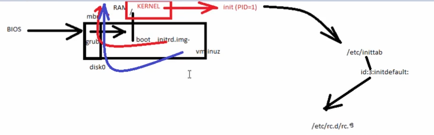

##### ubuntu-18.04.3-desktop-amd64.iso

```
Русский, русский, Minimal installation, mlapin,mlapinvb, 11111, вход в систему автоматически.
ps -aux | grep ssh
sudo apt-get install openssh-server -y
```

##### Сетевой диск

##### Вариант 1

`apt install cifs-utils` -  
`mkdir /mnt/share` -  
`mount -t cifs //192.168.1.102/avi /mnt/share -o username="freon",password="20304050",vers=1.0` -  
`umount /mnt/share` -  
`ls -l /mnt/` -  
`chmod a+x /mnt/share/` -  
`mount.cifs //192.168.1.102/avi /mnt/share -o username="freon",password="20304050",vers=1.0` -  
fstab  
`//192.168.1.102/avi /mnt/share cifs auto,username=freon,password=20304050,iocharset=utf8,dir_mode=0777,file_mode=0777,vers=1.0 0 0`

##### Вариант 2

[Как в Linux монтировать шару CIFS](https://www.dmosk.ru/miniinstruktions.php?mini=linux-cifs)

```
apt install  cifs-utils
mkdir /mnt/share
mount.cifs //192.168.0.110/MLAPINPC-ReadyCloud0 /mnt/share -o user="root"
umount /mnt/share
----
//192.168.0.110/MLAPINPC-ReadyCloud0    /mnt/share  cifs    auto,username="root",passwd="",iocharset=utf8,dir_mode=0777,file_mode=0777,vers=1.0 0   0
//192.168.0.110/MLAPINPC-ReadyCloud0    /mnt/share  cifs    user,rw,username="root",passwd=""   0   0
```

##### Дальше

`apt install chromium-browser` -  
`lsb_release -a` - Release: 14.04  
`do-release-upgrade`  
`service networking restart`

##### Jupyter

[Ubuntu 18.04 and later](https://askubuntu.com/questions/737094/jupyter-notebook-installation)  
[Running a notebook server](https://jupyter-notebook.readthedocs.io/en/stable/public_server.html)  
`c.NotebookApp.allow_origin = '*' #allow all origins` -  
`c.NotebookApp.ip = '0.0.0.0' # listen on all IPs` -  
[УСТАНОВКА CHROME В UBUNTU 18.04](https://losst.ru/ustanovka-chrome-v-ubuntu-18-04)

##### Ubuntu 18 2-я установка

'sudo apt install net-tools' - ifconfig  
'sudo apt-get install ssh'  
'sudo service ssh stop|start|restart'  
'sudo apt install vim'  
Менеджер приложений - vlc, utorrent, GITKRAKEN, ,  
`apt install chromium-browser` -  
`apt install jupyter` -  
`jupyter notebook` -  
[ГРАФИЧЕСКИЕ КЛИЕНТЫ GIT В LINUX](https://losst.ru/graficheskie-klienty-git-v-linux) `-` -  
`-` -  
`` -

`init 5` - графика  
`init 3` - консоль  
`init 0` - выключить  
`modinfo rt73usb` -  
`ls /lib/modules/4.4.0-142-generic/kernel/` - arch crypto drivers fs kernel lib mm net sound ubuntu virt

`find /lib/modules/4.4.0-142-generic/ -name *.ko` -  
`modinfo snd-usb-us122l` -

```
filename:       /lib/modules/4.4.0-142-generic/kernel/sound/usb/usx2y/snd-usb-us122l.ko
license:        GPL
description:    TASCAM US-122L Version 0.5
author:         Karsten Wiese <fzu@wemgehoertderstaat.de>
srcversion:     D3E03A6A052FEC15C1C9D0C
alias:          usb:v0644p8020d*dc*dsc*dp*ic*isc*ip*in*
alias:          usb:v0644p8021d*dc*dsc*dp*ic*isc*ip*in*
alias:          usb:v0644p800Fd*dc*dsc*dp*ic*isc*ip*in*
alias:          usb:v0644p800Ed*dc*dsc*dp*ic*isc*ip*in*
depends:        snd-usbmidi-lib,snd,snd-hwdep
retpoline:      Y
intree:         Y
vermagic:       4.4.0-142-generic SMP mod_unload modversions retpoline
parm:           index:Index value for US-122L. (array of int)
parm:           id:ID string for US-122L. (array of charp)
parm:           enable:Enable US-122L. (array of bool)
```

`modinfo xfs` -  
`modinfo reiserfs` -  
`-` -

`lsmod` -  
`insmod` -  
`rmmod` -  
`man modprobe` -  
`modprobe -r e1000` -  
`root@server:~# ls /lib/modules/4.4.0-142-generic/kernel/drivers/net/ethernet/intel/e1000/` - e1000.ko  
`insmode /lib/modules/4.4.0-142-generic/kernel/drivers/net/ethernet/intel/e1000/e1000.ko` -  
`locate e1000.ko` - /lib/modules/4.4.0-142-generic/kernel/drivers/net/ethernet/intel/e1000/e1000.ko  
`sysctl` - configure kernel parameters at runtime  
`less /etc/sysctl.conf` -  
`net.ipv4.ip_forward=1` - enable packet forwarding маршрутизацию транзитных IP-пакетов, т.е. тех пакетов, которые не предназначены именно для вашего компьютера  
`sysctl -p` - Load in sysctl settings from the file specified or /etc/sysctl.conf if none given.  
`runlevel` - N 2  
`telinit 5` - change system runlevel  
`pstree` - display a tree of processes  
`-p` - Show PIDs. PIDs are shown as decimal numbers in parentheses after each process name. -p implicitly disables compaction.  
`ps aux` -  
`` -